# Machine Learning Course Project. Human Activity Recognition

Andrey Vlasenko

10.04.2017

# Introduction

Using devices such as Jawbone Up, Nike FuelBand, and Fitbit it is now possible to collect a large amount of data about personal activity relatively inexpensively. These type of devices are part of the quantified self movement – a group of enthusiasts who take measurements about themselves regularly to improve their health, to find patterns in their behavior, or because they are tech geeks. One thing that people regularly do is quantify how much of a particular activity they do, but they rarely quantify how well they do it. In this project, your goal will be to use data from accelerometers on the belt, forearm, arm, and dumbell of 6 participants. They were asked to perform barbell lifts correctly and incorrectly in 5 different ways. More information is available from the website here http://groupware.les.inf.puc-rio.br/har.

The goal of the project is to predict the manner in which they did the exercise. This is the “classe” variable in the training set. You may use any of the other variables to predict with. You should create a report describing how you built your model, how you used cross validation, what you think the expected out of sample error is, and why you made the choices you did. You will also use your prediction model to predict 20 different test cases.

```r
rm(list=ls()) # loading libraries
library(caret); library(randomForest);
library(rpart); library(rpart.plot); library(plyr)
library(gbm); library(e1071); library(MASS)
```

# Data preprocessing

Loading and clearing the data.

```r
training<-read.csv("https://d396qusza40orc.cloudfront.net/predmachlearn/pml-training.csv",
                   na.strings=c("", "NA", "NULL", "#DIV/0!")) # there are NA values in the data
testing<-read.csv("https://d396qusza40orc.cloudfront.net/predmachlearn/pml-testing.csv",
                   na.strings=c("", "NA", "NULL", "#DIV/0!")) # there are NA values in the data
c(dim(training),dim(testing)) # dimensions of training and testing sets without NA vars
```

```
## [1] 19622   160    20   160
```

```r
table(training$classe) # there are 5 outcomes.
```

```
##
##    A    B    C    D    E
## 5580 3797 3422 3216 3607
```

```r
NAVals <- apply(is.na(training),2,sum)/dim(training)[1] # share of NA values in data
NAVals <- NAVals[NAVals>0.95]; NAnms<-names(NAVals); # NAnms - names of useless variables
trnSet <- training[,!(names(training) %in% NAnms)] # removing NA variables from training
tstSet <- testing[,!(names(training) %in% NAnms)] # removing NA variables from testing
trnSet <- trnSet[,-c(1:7)] # we have to remove first 7 variables linked with time
tstSet <- tstSet[,-c(1:7)] # and number of the observations to avoid overfitting of the model
c(dim(trnSet),dim(tstSet)) # dimensions of training and testing sets without NA vars
```

```
## [1] 19622    53    20    53
```

```r
str(trnSet)
```

```
## 'data.frame':    19622 obs. of  53 variables:
##  $ roll_belt           : num  1.41 1.41 1.42 1.48 1.48 1.45 1.42 1.42 1.43 1.45 ...
##  $ pitch_belt          : num  8.07 8.07 8.07 8.05 8.07 8.06 8.09 8.13 8.16 8.17 ...
##  $ yaw_belt            : num  -94.4 -94.4 -94.4 -94.4 -94.4 -94.4 -94.4 -94.4 -94.4 -94.4 ...
##  $ total_accel_belt    : int  3 3 3 3 3 3 3 3 3 3 ...
##  $ gyros_belt_x        : num  0 0.02 0 0.02 0.02 0.02 0.02 0.02 0.02 0.03 ...
##  $ gyros_belt_y        : num  0 0 0 0 0.02 0 0 0 0 0 ...
##  $ gyros_belt_z        : num  -0.02 -0.02 -0.02 -0.03 -0.02 -0.02 -0.02 -0.02 -0.02 0 ...
##  $ accel_belt_x        : int  -21 -22 -20 -22 -21 -21 -22 -22 -20 -21 ...
##  $ accel_belt_y        : int  4 4 5 3 2 4 3 4 2 4 ...
##  $ accel_belt_z        : int  22 22 23 21 24 21 21 21 24 22 ...
##  $ magnet_belt_x       : int  -3 -7 -2 -6 -6 0 -4 -2 1 -3 ...
##  $ magnet_belt_y       : int  599 608 600 604 600 603 599 603 602 609 ...
##  $ magnet_belt_z       : int  -313 -311 -305 -310 -302 -312 -311 -313 -312 -308 ...
##  $ roll_arm            : num  -128 -128 -128 -128 -128 -128 -128 -128 -128 -128 ...
```

[output cut: 39 more lines]

```r
ValsOfVars<-apply(trnSet, 2, function(x)length(unique(x))) # Number of values for each variable
length(ValsOfVars[ValsOfVars<2]) # there are no meaningless variables in data (with only 1 value)
```

```
## [1] 0
```

There are 53 variables (52 predictors) in training (19622 rows) and testing (20 questions of the final test) data sets.

# Modeling

Slicing training data set to training and testing sets to estimate the quality (accuracy) of the models.

```r
set.seed(1435)
inTrain <- createDataPartition(y=trnSet$classe, p = 0.60, list=FALSE)
trnSet_trn <- trnSet[inTrain,] # training set
trnSet_tst <- trnSet[-inTrain,] # testing set
```

Let’s fit the models. We’ll take into account the following models: * random forest, * decision tree, * stochastic gradient boosting, * linear discriminant analysis, * support vector machine.

```r
set.seed(125195)
model_RF <- randomForest(classe ~ ., data=trnSet_trn, importance = TRUE)
model_DT <- rpart(classe ~ ., data=trnSet_trn, method="class")
model_gbm <- train(classe ~ ., data=trnSet_trn, method="gbm")
model_lda <- train(classe ~ ., data=trnSet_trn, method="lda")
model_svm <- svm(classe ~ ., data=trnSet_trn)
```

## Random forest model results

```r
prediction_RF <- predict(model_RF, trnSet_tst)
ConMx <- confusionMatrix(prediction_RF, trnSet_tst$classe)
print(ConMx)
```

```
## Confusion Matrix and Statistics
##
##           Reference
## Prediction    A    B    C    D    E
##          A 2232   12    0    0    0
##          B    0 1503    4    0    0
##          C    0    3 1362   24    1
##          D    0    0    2 1258    4
##          E    0    0    0    4 1437
##
## Overall Statistics
##
##                Accuracy : 0.9931
##                  95% CI : (0.991, 0.9948)
##     No Information Rate : 0.2845
##     P-Value [Acc > NIR] : < 2.2e-16
##
##                   Kappa : 0.9913
##  Mcnemar's Test P-Value : NA
##
## Statistics by Class:
##
##                      Class: A Class: B Class: C Class: D Class: E
## Sensitivity            1.0000   0.9901   0.9956   0.9782   0.9965
## Specificity            0.9979   0.9994   0.9957   0.9991   0.9994
## Pos Pred Value         0.9947   0.9973   0.9799   0.9953   0.9972
## Neg Pred Value         1.0000   0.9976   0.9991   0.9957   0.9992
## Prevalence             0.2845   0.1935   0.1744   0.1639   0.1838
## Detection Rate         0.2845   0.1916   0.1736   0.1603   0.1832
## Detection Prevalence   0.2860   0.1921   0.1772   0.1611   0.1837
## Balanced Accuracy      0.9989   0.9947   0.9956   0.9887   0.9980
```

```r
head(apply(-varImp(model_RF),2,order))
```

```
##       A  B  C  D  E
## [1,]  3  2 39  3  1
## [2,] 39  1  1  1  3
## [3,]  1  3 38 39 39
## [4,] 38 39  3 38 41
## [5,] 41 41 41 41 38
## [6,]  2 38  2  2  2
```

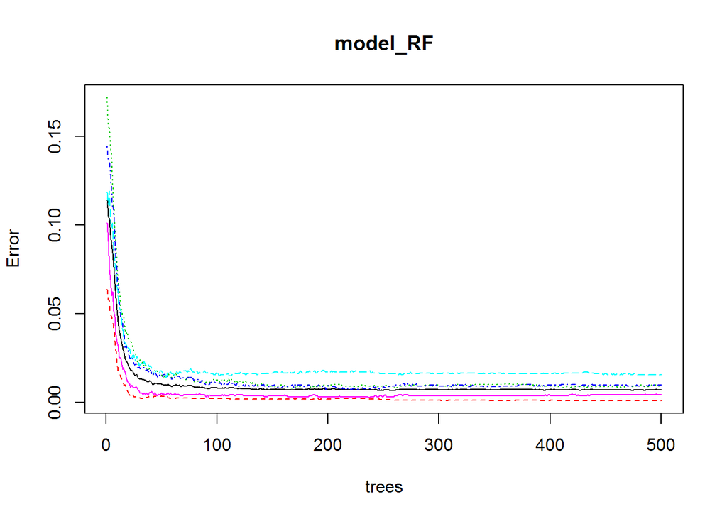

```r
plot(model_RF)
```

## Decision tree model results

```r
prediction_DT <- predict(model_DT, trnSet_tst, type="class")
ConMx2 <- confusionMatrix(prediction_DT, trnSet_tst$classe)
print(ConMx2)
```

```
## Confusion Matrix and Statistics
##
##           Reference
## Prediction    A    B    C    D    E
##          A 1946  234   74   67   81
##          B   96  972  101   95  125
##          C   39  146  933   85   71
##          D   97   57  235  951  159
##          E   54  109   25   88 1006
##
## Overall Statistics
##
##                Accuracy : 0.7402
##                  95% CI : (0.7304, 0.7499)
##     No Information Rate : 0.2845
##     P-Value [Acc > NIR] : < 2.2e-16
##
##                   Kappa : 0.6708
##  Mcnemar's Test P-Value : < 2.2e-16
##
## Statistics by Class:
##
##                      Class: A Class: B Class: C Class: D Class: E
## Sensitivity            0.8719   0.6403   0.6820   0.7395   0.6976
## Specificity            0.9188   0.9341   0.9474   0.9165   0.9569
## Pos Pred Value         0.8102   0.6998   0.7323   0.6344   0.7847
## Neg Pred Value         0.9475   0.9154   0.9338   0.9472   0.9336
## Prevalence             0.2845   0.1935   0.1744   0.1639   0.1838
## Detection Rate         0.2480   0.1239   0.1189   0.1212   0.1282
## Detection Prevalence   0.3061   0.1770   0.1624   0.1911   0.1634
## Balanced Accuracy      0.8953   0.7872   0.8147   0.8280   0.8273
```

```r
order(-varImp(model_DT))
```

```
##  [1] 22 15 23 16 28  5 20 18 24 26 14  3 25 12 27 19 10  1 13  6  9 21  4
## [24]  2 11 17  8  7 29 30 31 32 33 34 35 36 37 38 39 40 41 42 43 44 45 46
## [47] 47 48 49 50 51 52
```

## Stochastic Gradient Boosting model results

```r
prediction_gbm <- predict(model_gbm, trnSet_tst)
ConMx3 <- confusionMatrix(prediction_gbm, trnSet_tst$classe)
print(ConMx3)
```

```
## Confusion Matrix and Statistics
##
##           Reference
## Prediction    A    B    C    D    E
##          A 2189   69    0    1    3
##          B   27 1392   21    0   18
##          C    9   54 1330   51   12
##          D    7    2   14 1226   25
##          E    0    1    3    8 1384
##
## Overall Statistics
##
##                Accuracy : 0.9586
##                  95% CI : (0.9539, 0.9629)
##     No Information Rate : 0.2845
##     P-Value [Acc > NIR] : < 2.2e-16
##
##                   Kappa : 0.9476
##  Mcnemar's Test P-Value : < 2.2e-16
##
## Statistics by Class:
##
##                      Class: A Class: B Class: C Class: D Class: E
## Sensitivity            0.9807   0.9170   0.9722   0.9533   0.9598
## Specificity            0.9870   0.9896   0.9805   0.9927   0.9981
## Pos Pred Value         0.9677   0.9547   0.9135   0.9623   0.9914
## Neg Pred Value         0.9923   0.9803   0.9941   0.9909   0.9910
## Prevalence             0.2845   0.1935   0.1744   0.1639   0.1838
## Detection Rate         0.2790   0.1774   0.1695   0.1563   0.1764
## Detection Prevalence   0.2883   0.1858   0.1856   0.1624   0.1779
## Balanced Accuracy      0.9839   0.9533   0.9764   0.9730   0.9790
```

## Linear Discriminant Analysis model results

```r
prediction_lda <- predict(model_lda, trnSet_tst)
ConMx4 <- confusionMatrix(prediction_lda, trnSet_tst$classe)
print(ConMx4)
```

```
## Confusion Matrix and Statistics
##
##           Reference
## Prediction    A    B    C    D    E
##          A 1841  244  137   85   66
##          B   57  972  123   46  269
##          C  159  171  879  153  121
##          D  170   56  187  952  139
##          E    5   75   42   50  847
##
## Overall Statistics
##
##                Accuracy : 0.6998
##                  95% CI : (0.6896, 0.71)
##     No Information Rate : 0.2845
##     P-Value [Acc > NIR] : < 2.2e-16
##
##                   Kappa : 0.6198
##  Mcnemar's Test P-Value : < 2.2e-16
##
## Statistics by Class:
##
##                      Class: A Class: B Class: C Class: D Class: E
## Sensitivity            0.8248   0.6403   0.6425   0.7403   0.5874
## Specificity            0.9052   0.9218   0.9068   0.9159   0.9731
## Pos Pred Value         0.7758   0.6626   0.5927   0.6330   0.8312
## Neg Pred Value         0.9286   0.9144   0.9231   0.9473   0.9128
## Prevalence             0.2845   0.1935   0.1744   0.1639   0.1838
## Detection Rate         0.2346   0.1239   0.1120   0.1213   0.1080
## Detection Prevalence   0.3024   0.1870   0.1890   0.1917   0.1299
## Balanced Accuracy      0.8650   0.7810   0.7747   0.8281   0.7803
```

## Support vector machine model results

```r
prediction_svm <- predict(model_svm, trnSet_tst)
ConMx5 <- confusionMatrix(prediction_svm, trnSet_tst$classe)
print(ConMx5)
```

```
## Confusion Matrix and Statistics
##
##           Reference
## Prediction    A    B    C    D    E
##          A 2224  134    2    2    3
##          B    3 1317   44   12   15
##          C    5   64 1282  114   48
##          D    0    3   37 1154   29
##          E    0    0    3    4 1347
##
## Overall Statistics
##
##                Accuracy : 0.9335
##                  95% CI : (0.9277, 0.9389)
##     No Information Rate : 0.2845
##     P-Value [Acc > NIR] : < 2.2e-16
##
##                   Kappa : 0.9157
##  Mcnemar's Test P-Value : < 2.2e-16
##
## Statistics by Class:
##
##                      Class: A Class: B Class: C Class: D Class: E
## Sensitivity            0.9964   0.8676   0.9371   0.8974   0.9341
## Specificity            0.9749   0.9883   0.9643   0.9895   0.9989
## Pos Pred Value         0.9404   0.9468   0.8473   0.9436   0.9948
## Neg Pred Value         0.9985   0.9689   0.9864   0.9801   0.9854
## Prevalence             0.2845   0.1935   0.1744   0.1639   0.1838
## Detection Rate         0.2835   0.1679   0.1634   0.1471   0.1717
## Detection Prevalence   0.3014   0.1773   0.1928   0.1559   0.1726
## Balanced Accuracy      0.9856   0.9279   0.9507   0.9434   0.9665
```

# Conclusion

RF demonstrate the highest accuracy (0.99). Also high accuracy was in gbm and svm models (0.96 and 0.93). Lowest accuracy was in lda (0.7) and rpart (0.74)

# Final test predictions

```r
prediction <- rbind(predict(model_RF, tstSet),predict(model_DT, tstSet,type="class"),
                    predict(model_gbm, tstSet),predict(model_lda, tstSet),
                    predict(model_svm, tstSet))
Pred_Fin <- as.data.frame(x=matrix(c("A","B","C","D","E")[prediction], ncol = 20, nrow = 5),
                          row.names = c("RF","DT","gbm","lda","svm"))
print(Pred_Fin)
```

```
##     V1 V2 V3 V4 V5 V6 V7 V8 V9 V10 V11 V12 V13 V14 V15 V16 V17 V18 V19 V20
## RF   B  A  B  A  A  E  D  B  A   A   B   C   B   A   E   E   A   B   B   B
## DT   A  A  A  D  A  C  D  E  A   A   B   C   B   A   D   E   A   B   A   B
## gbm  B  A  B  A  A  E  D  B  A   A   B   C   B   A   E   E   A   B   B   B
## lda  B  A  B  C  C  E  D  D  A   A   D   A   B   A   E   A   A   B   B   B
## svm  B  A  A  A  A  E  D  B  A   A   B   C   B   A   E   E   A   B   B   B
```

For final quiz we’ll use the results of the random forest model which demonstrate the best accuracy (0.99).